# data_exploration

<h1 id="Data-Exploration">Data Exploration</h1>

<h2 id="Setup">Setup</h2>

<h3 id="Imports">Imports</h3>

```python
import pandas as pd
import numpy as np
import matplotlib.pyplot as plt
import seaborn as sns
import math
```

```python
import sys
sys.path.append("..")
from my_project.fileManager import FileManager
```

<h3 id="Auxiliar-functions">Auxiliar functions</h3>

```python
def inspect(df):
    print(f"Shape: {df.shape}")
    print(f"Columns: {list(df.columns)}")
    print(f"Data types:\n{df.dtypes}")
    print()
```

<h3 id="Constants">Constants</h3>

```python
RAW_FILE = "../data/raw/automobile_dataset"
PROCESSED_TRAIN_FILE = "../data/processed/automobile_dataset"
PROCESSED_TEST_FILE = "../data/processed/automobile_test"
EXPLORATION_IMAGES_FOLDER = "../reports/figures/exploration/"
```

<h2 id="Data-loading">Data loading</h2>

<p>We created a FileManager class to make it easier to save and load our dataset using different file formats. The class supports CSV, Parquet, Feather, and Pickle files. The class automatically adds the correct file extension, so we only need to provide the file name. This makes the code more flexible and avoids having to write different functions for each file format.</p>

```python
fM = FileManager()
```

```python
fM.set_format("csv")
df = fM.read(RAW_FILE)

display(df)
```

<style scoped> .dataframe tbody tr th:only-of-type { vertical-align: middle; } .dataframe tbody tr th { vertical-align: top; } .dataframe thead th { text-align: right; } </style> <thead> <th></th> <th>Make</th> <th>Model</th> <th>Year</th> <th>Fuel_Type</th> <th>Transmission</th> <th>Engine_Size</th> <th>Mileage</th> <th>Horsepower</th> <th>Torque</th> <th>Owners</th> <th>Accident_History</th> <th>Service_History</th> <th>Color</th> <th>Body_Type</th> <th>Drivetrain</th> <th>Fuel_Efficiency</th> <th>Location</th> <th>Selling_Price</th> </thead> <tbody> <th>0</th> <th>1</th> <th>2</th> <th>3</th> <th>4</th> <th>...</th> <th>5495</th> <th>5496</th> <th>5497</th> <th>5498</th> <th>5499</th> </tbody>

| Mercedes-Benz | GLE | 2024 | Petrol | Automatic | 2.3 | 100 | 186.0 | 196.0 | 1 | 0.0 | NaN | Silver | SUV | AWD | 30.0 | IL | 64140 |
| --- | --- | --- | --- | --- | --- | --- | --- | --- | --- | --- | --- | --- | --- | --- | --- | --- | --- |
| Hyundai | Tucson | 2008 | Petrol | Automatic | 2.3 | 387035 | 189.0 | 190.0 | 4 | 0.0 | NaN | Blue | SUV | FWD | 35.0 | FL | 500 |
| Volkswagen | Golf | 2021 | Hybrid | NaN | 1.9 | 46054 | 158.0 | 153.0 | 1 | 0.0 | Partial Service | Gray | Hatchback | AWD | 43.0 | NY | 16429 |
| Chevrolet | Tahoe | 2005 | Petrol | NaN | 2.2 | 141302 | 169.0 | 165.0 | 5 | 1.0 | No Service | Blue | SUV | AWD | NaN | FL | 2199 |
| Toyota | Camry | 2022 | Petrol | Automatic | 1.9 | 32813 | 149.0 | 141.0 | 1 | 0.0 | Full Service | Brown | Sedan | FWD | 38.0 | CA | 21792 |
| ... | ... | ... | ... | ... | ... | ... | ... | ... | ... | ... | ... | ... | ... | ... | ... | ... | ... |
| Volkswagen | Tiguan | 2022 | Petrol | Automatic | NaN | 29506 | 161.0 | NaN | 1 | 0.0 | Partial Service | Black | SUV | AWD | 33.0 | GA | 20333 |
| Nissan | Pathfinder | 2006 | Petrol | Automatic | 3.1 | 287332 | 243.0 | 227.0 | 5 | 1.0 | No Service | Gray | SUV | AWD | NaN | NY | 500 |
| BMW | X3 | 2013 | Petrol | Automatic | 2.2 | 95961 | 171.0 | 152.0 | 2 | 1.0 | No Service | Blue | SUV | AWD | 32.0 | MI | 9882 |
| Volkswagen | Golf | 2020 | Hybrid | Automatic | 1.5 | 56643 | 135.0 | 125.0 | 2 | 1.0 | No Service | White | Hatchback | FWD | 57.0 | NY | 10474 |
| Chevrolet | Tahoe | 2011 | Petrol | Automatic | 2.1 | 169929 | 168.0 | 158.0 | 3 | 1.0 | NaN | Gray | SUV | AWD | NaN | MI | 6193 |

<p>5500 rows × 18 columns</p>

<p>Our dataset focuses on analyzing the selling price of used cars. It contains **5500 records** and **18 variables** that describe different aspects of each vehicle: its specifications, ownership history, condition, and other contextual information. It contains a mixture of numerical and categorical values. The most important variable is the **Selling_Price**, which is the target value which our machine learning models will try to predict as new instances come through.</p>

```python
inspect(df)
```

```
Shape: (5500, 18)
Columns: ['Make', 'Model', 'Year', 'Fuel_Type', 'Transmission', 'Engine_Size', 'Mileage', 'Horsepower', 'Torque', 'Owners', 'Accident_History', 'Service_History', 'Color', 'Body_Type', 'Drivetrain', 'Fuel_Efficiency', 'Location', 'Selling_Price']
Data types:
Make                 object
Model                object
Year                  int64
Fuel_Type            object
Transmission         object
Engine_Size         float64
Mileage               int64
Horsepower          float64
Torque              float64
Owners                int64
Accident_History    float64
Service_History      object
Color                object
Body_Type            object
Drivetrain           object
Fuel_Efficiency     float64
Location             object
Selling_Price         int64
dtype: object
```

<h2 id="Memory-optimization">Memory optimization</h2>

<p>We check how much memory our dataset is using and then try to reduce it by optimizing the data types. First, we calculate the initial memory usage of the DataFrame. Then, we go through all the columns and change their data types to more efficient ones when possible. This helps make the dataset more memory-efficient, which can be useful when working with larger datasets.</p>

```python
# Initial memory usage
initial_size = df.memory_usage(deep=True).sum() / (1024 ** 2)
print(f"Initial memory usage: {initial_size:.2f} MB")

# Optimize data types
for col in list(df.columns):
    if df.dtypes[col] == "int64":
        df[col] = pd.to_numeric(df[col], downcast='integer')
        size = df.memory_usage(deep=True).sum() / (1024 ** 2)
        #print(f"Memory usage after downcasting to integer: {size:.2f} MB")
    if df.dtypes[col] == "float64":
        df[col] = pd.to_numeric(df[col], downcast='float')
        size = df.memory_usage(deep=True).sum() / (1024 ** 2)
        #print(f"Memory usage after downcasting to float: {size:.2f} MB")
    if df.dtypes[col] == "str" or df.dtypes[col] == "object":
        df[col] = df[col].astype('category')
        size = df.memory_usage(deep=True).sum() / (1024 ** 2)
        #print(f"Memory usage after changing to categorical column: {size:.2f} MB")

# Optimized memory usage
final_size = df.memory_usage(deep=True).sum() / (1024 ** 2)
print(f"Final memory usage: {final_size:.2f} MB")
print(f"Reduction of {(1 - final_size / initial_size) * 100:.2f}%")
```

```
Initial memory usage: 2.90 MB
Final memory usage: 0.22 MB
Reduction of 92.51%
```

```python
inspect(df)
```

```
Shape: (5500, 18)
Columns: ['Make', 'Model', 'Year', 'Fuel_Type', 'Transmission', 'Engine_Size', 'Mileage', 'Horsepower', 'Torque', 'Owners', 'Accident_History', 'Service_History', 'Color', 'Body_Type', 'Drivetrain', 'Fuel_Efficiency', 'Location', 'Selling_Price']
Data types:
Make                category
Model               category
Year                   int16
Fuel_Type           category
Transmission        category
Engine_Size          float32
Mileage                int32
Horsepower           float32
Torque               float32
Owners                  int8
Accident_History     float32
Service_History     category
Color               category
Body_Type           category
Drivetrain          category
Fuel_Efficiency      float32
Location            category
Selling_Price          int32
dtype: object
```

<h2 id="Missing-values">Missing values</h2>

<p>Before doing anything, we checked the dataset for missing values using insull().sum(). This allows us to identify in which variables we had these kind of observations. The preprocessing step is important because most machine learning algorithms cannot work directly with missing data.</p>

```python
print("Missing values:")
print(df.isnull().sum() > 0)
print()

print("Fill missing numerical values:")
dictionary = {}

# Numerical fixes
dfk = df.isnull().sum() > 0
for col in list(df.columns):
    if dfk[col] and df.dtypes[col] != "category":
        dictionary[col] = dfk[col].mean()
df.fillna(dictionary)

# Categorical fixes
print("Drop rows with any missing categorical values:")
print("Categorical Fixes:")
df = df.dropna()
display(df)

# Missing values:
print(df.isnull().sum() > 0)
print()
```

```
Missing values:
Make                False
Model               False
Year                False
Fuel_Type           False
Transmission         True
Engine_Size          True
Mileage             False
Horsepower           True
Torque               True
Owners              False
Accident_History     True
Service_History      True
Color                True
Body_Type           False
Drivetrain          False
Fuel_Efficiency      True
Location             True
Selling_Price       False
dtype: bool

Fill missing numerical values:
Drop rows with any missing categorical values:
Categorical Fixes:
```

<style scoped> .dataframe tbody tr th:only-of-type { vertical-align: middle; } .dataframe tbody tr th { vertical-align: top; } .dataframe thead th { text-align: right; } </style> <thead> <th></th> <th>Make</th> <th>Model</th> <th>Year</th> <th>Fuel_Type</th> <th>Transmission</th> <th>Engine_Size</th> <th>Mileage</th> <th>Horsepower</th> <th>Torque</th> <th>Owners</th> <th>Accident_History</th> <th>Service_History</th> <th>Color</th> <th>Body_Type</th> <th>Drivetrain</th> <th>Fuel_Efficiency</th> <th>Location</th> <th>Selling_Price</th> </thead> <tbody> <th>4</th> <th>7</th> <th>15</th> <th>17</th> <th>21</th> <th>...</th> <th>5478</th> <th>5479</th> <th>5491</th> <th>5497</th> <th>5498</th> </tbody>

| Toyota | Camry | 2022 | Petrol | Automatic | 1.9 | 32813 | 149.0 | 141.0 | 1 | 0.0 | Full Service | Brown | Sedan | FWD | 38.0 | CA | 21792 |
| --- | --- | --- | --- | --- | --- | --- | --- | --- | --- | --- | --- | --- | --- | --- | --- | --- | --- |
| Mercedes-Benz | C-Class | 2022 | Petrol | Automatic | 2.3 | 32133 | 180.0 | 162.0 | 1 | 0.0 | Partial Service | Green | Sedan | FWD | 35.0 | NY | 31416 |
| Mercedes-Benz | C-Class | 2010 | Petrol | Manual | 2.0 | 17138 | 169.0 | 160.0 | 3 | 0.0 | Partial Service | Blue | Sedan | FWD | 27.0 | NC | 11728 |
| Chevrolet | Tahoe | 2011 | Petrol | Automatic | 3.3 | 264441 | 258.0 | 252.0 | 4 | 0.0 | Partial Service | Gray | SUV | AWD | 22.0 | TX | 3395 |
| Audi | Q7 | 2016 | Petrol | Automatic | 3.1 | 111537 | 243.0 | 219.0 | 2 | 0.0 | Partial Service | Blue | SUV | AWD | 21.0 | FL | 23314 |
| ... | ... | ... | ... | ... | ... | ... | ... | ... | ... | ... | ... | ... | ... | ... | ... | ... | ... |
| Audi | A6 | 2010 | Petrol | Manual | 2.1 | 155818 | 169.0 | 176.0 | 3 | 0.0 | Full Service | Red | Sedan | FWD | 41.0 | FL | 9714 |
| Honda | Accord | 2023 | Petrol | Automatic | 2.4 | 100 | 199.0 | 192.0 | 1 | 0.0 | Partial Service | Green | Sedan | FWD | 33.0 | GA | 23937 |
| Nissan | Pathfinder | 2020 | Petrol | Automatic | 2.7 | 79498 | 212.0 | 204.0 | 1 | 0.0 | Partial Service | Gray | SUV | AWD | 24.0 | OH | 18345 |
| BMW | X3 | 2013 | Petrol | Automatic | 2.2 | 95961 | 171.0 | 152.0 | 2 | 1.0 | No Service | Blue | SUV | AWD | 32.0 | MI | 9882 |
| Volkswagen | Golf | 2020 | Hybrid | Automatic | 1.5 | 56643 | 135.0 | 125.0 | 2 | 1.0 | No Service | White | Hatchback | FWD | 57.0 | NY | 10474 |

<p>1329 rows × 18 columns</p>

```
Make                False
Model               False
Year                False
Fuel_Type           False
Transmission        False
Engine_Size         False
Mileage             False
Horsepower          False
Torque              False
Owners              False
Accident_History    False
Service_History     False
Color               False
Body_Type           False
Drivetrain          False
Fuel_Efficiency     False
Location            False
Selling_Price       False
dtype: bool
```

<h2 id="Exploration">Exploration</h2>

<h4 id="1.-Car-Model-Count">1. Car Model Count</h4>

```python
plt.figure(figsize=(10, 5))
car_counts = df["Make"].value_counts()
plt.bar(car_counts.index, car_counts.values , color='royalblue')
plt.xlabel("Car Model")
plt.ylabel("Count")
plt.xticks(rotation=90)
plt.title("Automobile Dataset: Car Model Count")
plt.tight_layout()
plt.savefig(f"{EXPLORATION_IMAGES_FOLDER}car_model_count.png", dpi=300)

plt.close() # IF WE DONT WANT TO SHOW THE IMAGE.
plt.show() # IF WE WANT TO SHOW THE IMAGE
```

<h4 id="2.-Heatmap">2. Heatmap</h4>

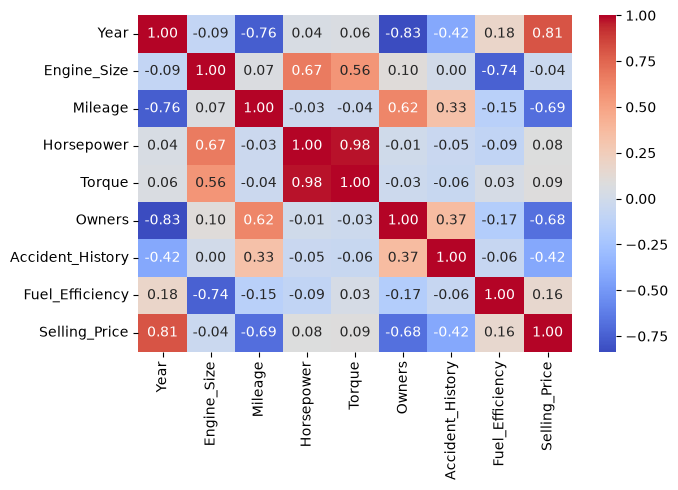

```python
corr = df.select_dtypes(include=np.number).corr()

plt.figure(figsize=(7, 5))

sns.heatmap( corr, annot=True, cmap='coolwarm' , fmt=".2f")

plt.tight_layout()
plt.savefig(f"{EXPLORATION_IMAGES_FOLDER}heatmap.png", dpi=300)

# plt.close() # IF WE DONT WANT TO SHOW THE IMAGE.
plt.show() # IF WE WANT TO SHOW THE IMAGE
```

<p>We can see some high correlations between several variables:</p>

- Horsepower and Torque have a very strong positive correlation (0.98). This means that cars with higher horsepower usually also have higher torque.
- Selling_Price and Year have a positive correlation (0.81). In general, newer cars tend to have a higher selling price.
- Selling_Price has a negative correlation with Mileage (-0.69) and Owners (-0.68). This means that cars with higher mileage or more previous owners tend to have a lower selling price.
- Engine_Size and Fuel_Efficiency have a negative correlation (-0.74). As the engine size increases, fuel efficiency tends to decrease.
- Engine_Size also has a positive correlation with Horsepower (0.67) and Torque (0.56). This suggests that cars with larger engines tend to have more horsepower and torque.

<h4 id="3.-Pruebas-de-Scatterplot">3. Pruebas de Scatterplot</h4>

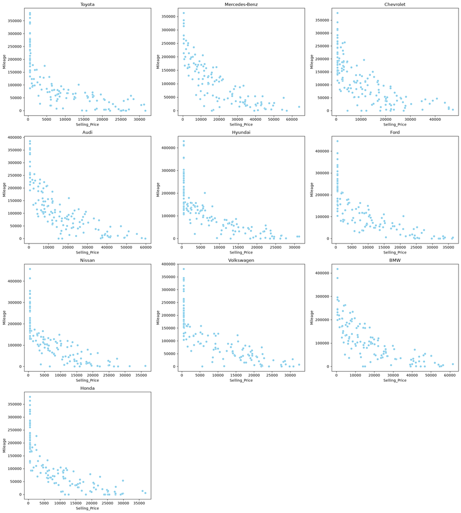

```python
makes = df["Make"].unique()
n = len(makes)

cols = 3
rows = math.ceil(n / cols)

fig, axes = plt.subplots(rows, cols, figsize=(18, 5 * rows))
axes = axes.flatten()

for ax, make in zip(axes, makes):
    df_make = df[df["Make"] == make]

    sns.scatterplot(
        data=df_make,
        x="Selling_Price",
        y="Mileage",
        color="skyblue",
        ax=ax
    )

    ax.set_title(make)

# Eliminar ejes vacíos
for ax in axes[len(makes):]:
    fig.delaxes(ax)

plt.tight_layout()
plt.savefig(f"{EXPLORATION_IMAGES_FOLDER}scatterplots.png", dpi=300)

# plt.close() # IF WE DONT WANT TO SHOW THE IMAGE.
plt.show() # IF WE WANT TO SHOW THE IMAGE
```

<h4 id="%C2%A04.-Boxplot-by-Category"> 4. Boxplot by Category</h4>

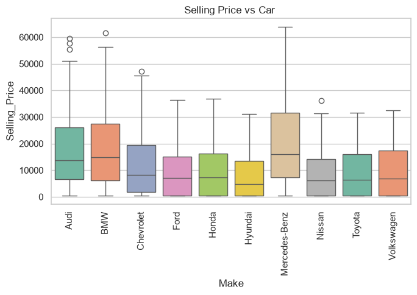

```python
sns.set_theme(style="whitegrid")
plt.figure(figsize=(7, 5))
sns.boxplot(data=df, x="Make", y="Selling_Price", palette="Set2")
plt.xticks(rotation=90)
plt.title("Selling Price vs Car ")
plt.tight_layout()

plt.savefig(f"{EXPLORATION_IMAGES_FOLDER}selling_vs_car.png", dpi=300)

# plt.close() # IF WE DONT WANT TO SHOW THE IMAGE.
plt.show() # IF WE WANT TO SHOW THE IMAGE
```

<p>Audi, BMW, and Mercedes-Benz have the highest selling prices in the dataset. These brands also include some of the most expensive vehicles, reflecting their position in the premium car market.</p>

<h4 id="5.-Seaborn-Pairplot-Experiments">5. Seaborn Pairplot Experiments</h4>

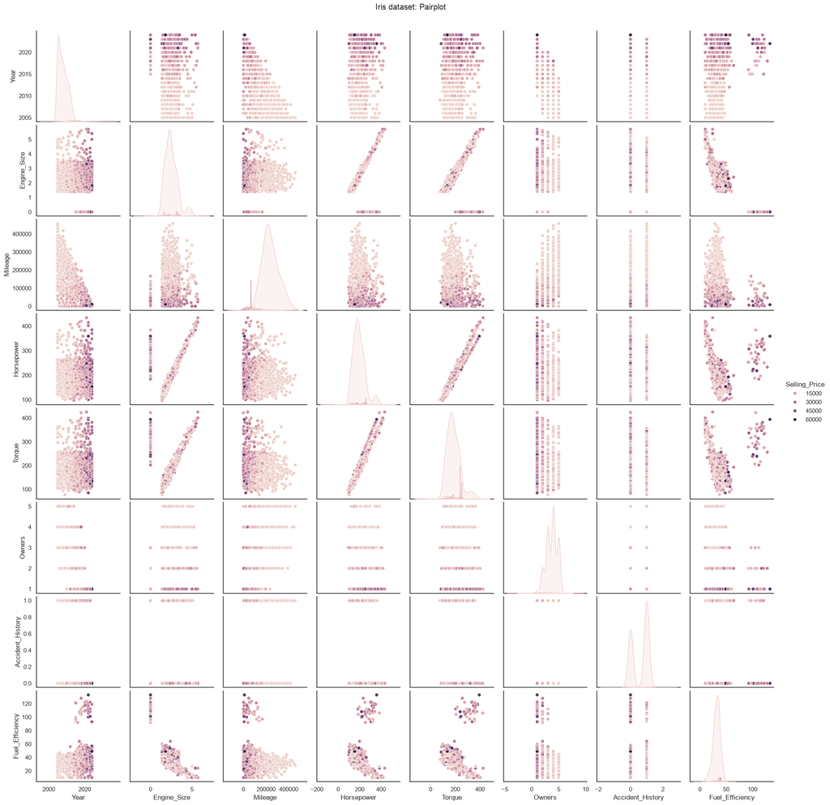

```python
sns.set_theme(style="white")
sns.pairplot(df, hue="Selling_Price", height=2.5)
plt.suptitle("Iris dataset: Pairplot", y=1.02)
plt.savefig(f"{EXPLORATION_IMAGES_FOLDER}pairplots.png", dpi=300)

# plt.close() # IF WE DONT WANT TO SHOW THE IMAGE.
plt.show() # IF WE WANT TO SHOW THE IMAGE
```

<h2 id="Categorical-to-numerical">Categorical to numerical</h2>

```python
print(df["Make"].nunique())
print(df["Color"].nunique())
print(df["Model"].nunique())
print(df["Service_History"].nunique())
print(df["Body_Type"].nunique())
print(df["Drivetrain"].nunique())
print(df["Location"].nunique())
```

```
10
8
40
3
5
4
10
```

<p>Machine learning models cannot work directly with categorical data, so these variables must be converted into a numerical format before training. That's why we did some encoding.</p>

- For **Service_History**, we used **ordinal encoding** because the categories have a natural order. A vehicle with no service history provides less information than one with a partial service history.
- For the **remaining categorical variables**, we applied **One-Hot Encoding**. This method creates a separate binary column for each category and avoids introducing relationships between categories that do not actually exist.

```python
# Ordinal for service (from no service to full service, hierarchy is preserved)
service_mapping = {
    "No Service": 0,
    "Partial Service": 1,
    "Full Service": 2
}

df["Service_History"] = df["Service_History"].map(service_mapping)


# OHE for the other categorical columns
categorical_columns = [
    "Make",
    "Model",
    "Fuel_Type",
    "Transmission",
    "Color",
    "Body_Type",
    "Drivetrain",
    "Location"
]

df = pd.get_dummies(
    df,
    columns=categorical_columns,
    dtype=int
)
```

```python
print(df.head())
print(df.dtypes)
print(df.shape)
print(df.columns)
```

```
    Year  Engine_Size  Mileage  Horsepower  Torque  Owners  Accident_History  \
4   2022          1.9    32813       149.0   141.0       1               0.0
7   2022          2.3    32133       180.0   162.0       1               0.0
15  2010          2.0    17138       169.0   160.0       3               0.0
17  2011          3.3   264441       258.0   252.0       4               0.0
21  2016          3.1   111537       243.0   219.0       2               0.0

   Service_History  Fuel_Efficiency  Selling_Price  ...  Location_CA  \
4                2             38.0          21792  ...            1
7                1             35.0          31416  ...            0
15               1             27.0          11728  ...            0
17               1             22.0           3395  ...            0
21               1             21.0          23314  ...            0

    Location_FL  Location_GA  Location_IL  Location_MI  Location_NC  \
4             0            0            0            0            0
7             0            0            0            0            0
15            0            0            0            0            1
17            0            0            0            0            0
21            1            0            0            0            0

    Location_NY  Location_OH  Location_PA  Location_TX
4             0            0            0            0
7             1            0            0            0
15            0            0            0            0
17            0            0            0            1
21            0            0            0            0

[5 rows x 93 columns]
Year             int16
Engine_Size    float32
Mileage          int32
Horsepower     float32
Torque         float32
                ...
Location_NC      int64
Location_NY      int64
Location_OH      int64
Location_PA      int64
Location_TX      int64
```

[output cut: 11 more lines]

```
       'Model_GLE', 'Model_Golf', 'Model_Highlander', 'Model_Malibu',
       'Model_Mustang', 'Model_Passat', 'Model_Pathfinder', 'Model_Pilot',
       'Model_Q5', 'Model_Q7', 'Model_RAV4', 'Model_Rogue', 'Model_Santa Fe',
       'Model_Sentra', 'Model_Silverado', 'Model_Sonata', 'Model_Tahoe',
       'Model_Tiguan', 'Model_Tucson', 'Model_X3', 'Model_X5',
       'Fuel_Type_Diesel', 'Fuel_Type_Electric', 'Fuel_Type_Hybrid',
       'Fuel_Type_Petrol', 'Transmission_Automatic', 'Transmission_Manual',
       'Color_Black', 'Color_Blue', 'Color_Brown', 'Color_Gray', 'Color_Green',
       'Color_Red', 'Color_Silver', 'Color_White', 'Body_Type_Coupe',
       'Body_Type_Hatchback', 'Body_Type_SUV', 'Body_Type_Sedan',
       'Body_Type_Truck', 'Drivetrain_4WD', 'Drivetrain_AWD', 'Drivetrain_FWD',
       'Drivetrain_RWD', 'Location_CA', 'Location_FL', 'Location_GA',
       'Location_IL', 'Location_MI', 'Location_NC', 'Location_NY',
       'Location_OH', 'Location_PA', 'Location_TX'],
      dtype='object')
```

<h2 id="Save-processed-data">Save processed data</h2>

```python
from sklearn.model_selection import train_test_split

# 80% training data
# 20% testing data
train_df, test_df = train_test_split(
    df,
    test_size=0.2,
    random_state=22
)
```

```python
fM.set_format("parquet")
fM.write(train_df, PROCESSED_TRAIN_FILE)
fM.write(test_df, PROCESSED_TEST_FILE)
```

<h2 id="Check-it-was-correctly-saved">Check it was correctly saved</h2>

```python
fM.set_format("parquet")
fdf = fM.read(PROCESSED_TRAIN_FILE)

display(fdf)
inspect(fdf)
```

<style scoped> .dataframe tbody tr th:only-of-type { vertical-align: middle; } .dataframe tbody tr th { vertical-align: top; } .dataframe thead th { text-align: right; } </style> <thead> <th></th> <th>Year</th> <th>Engine_Size</th> <th>Mileage</th> <th>Horsepower</th> <th>Torque</th> <th>Owners</th> <th>Accident_History</th> <th>Service_History</th> <th>Fuel_Efficiency</th> <th>Selling_Price</th> <th>...</th> <th>Location_CA</th> <th>Location_FL</th> <th>Location_GA</th> <th>Location_IL</th> <th>Location_MI</th> <th>Location_NC</th> <th>Location_NY</th> <th>Location_OH</th> <th>Location_PA</th> <th>Location_TX</th> </thead> <tbody> <th>633</th> <th>1028</th> <th>4550</th> <th>1056</th> <th>1063</th> <th>...</th> <th>1461</th> <th>4038</th> <th>3372</th> <th>497</th> <th>3692</th> </tbody>

| 2008 | 2.0 | 20347 | 167.0 | 151.0 | 5 | 1.0 | 1 | 35.0 | 3428 | ... | 0 | 1 | 0 | 0 | 0 | 0 | 0 | 0 | 0 | 0 |
| --- | --- | --- | --- | --- | --- | --- | --- | --- | --- | --- | --- | --- | --- | --- | --- | --- | --- | --- | --- | --- |
| 2016 | 2.2 | 64385 | 162.0 | 167.0 | 4 | 1.0 | 1 | 29.0 | 5850 | ... | 0 | 0 | 0 | 0 | 1 | 0 | 0 | 0 | 0 | 0 |
| 2013 | 2.5 | 158156 | 187.0 | 172.0 | 3 | 0.0 | 1 | 22.0 | 1281 | ... | 0 | 1 | 0 | 0 | 0 | 0 | 0 | 0 | 0 | 0 |
| 2013 | 2.5 | 131422 | 209.0 | 189.0 | 3 | 1.0 | 1 | 27.0 | 7586 | ... | 0 | 0 | 0 | 1 | 0 | 0 | 0 | 0 | 0 | 0 |
| 2008 | 3.5 | 270715 | 263.0 | 239.0 | 4 | 0.0 | 0 | 19.0 | 500 | ... | 0 | 0 | 0 | 1 | 0 | 0 | 0 | 0 | 0 | 0 |
| ... | ... | ... | ... | ... | ... | ... | ... | ... | ... | ... | ... | ... | ... | ... | ... | ... | ... | ... | ... | ... |
| 2005 | 3.3 | 377675 | 250.0 | 231.0 | 3 | 0.0 | 1 | 24.0 | 500 | ... | 0 | 0 | 0 | 0 | 0 | 0 | 0 | 0 | 1 | 0 |
| 2017 | 1.6 | 87365 | 122.0 | 103.0 | 1 | 0.0 | 0 | 43.0 | 15518 | ... | 0 | 0 | 0 | 1 | 0 | 0 | 0 | 0 | 0 | 0 |
| 2023 | 3.2 | 3623 | 243.0 | 246.0 | 1 | 0.0 | 1 | 23.0 | 24300 | ... | 0 | 0 | 0 | 0 | 0 | 0 | 0 | 0 | 0 | 1 |
| 2011 | 3.3 | 229650 | 238.0 | 223.0 | 3 | 1.0 | 1 | 24.0 | 7157 | ... | 0 | 0 | 0 | 0 | 0 | 0 | 0 | 1 | 0 | 0 |
| 2005 | 2.2 | 410673 | 175.0 | 169.0 | 5 | 0.0 | 1 | 33.0 | 500 | ... | 0 | 0 | 0 | 0 | 0 | 0 | 0 | 0 | 0 | 1 |

<p>1063 rows × 93 columns</p>

```
Shape: (1063, 93)
Columns: ['Year', 'Engine_Size', 'Mileage', 'Horsepower', 'Torque', 'Owners', 'Accident_History', 'Service_History', 'Fuel_Efficiency', 'Selling_Price', 'Make_Audi', 'Make_BMW', 'Make_Chevrolet', 'Make_Ford', 'Make_Honda', 'Make_Hyundai', 'Make_Mercedes-Benz', 'Make_Nissan', 'Make_Toyota', 'Make_Vol…
Data types:
Year             int16
Engine_Size    float32
Mileage          int32
Horsepower     float32
Torque         float32
                ...
Location_NC      int64
Location_NY      int64
Location_OH      int64
Location_PA      int64
Location_TX      int64
Length: 93, dtype: object
```